# Python

## Где применяется Python: 3 основных назначения языка

1. Веб-разработка
2. Обработка данных (включая машинное обучение, анализ и визуализацию данных)
3. Автоматизация процессов

## Python в крупных компаниях

- В Amazon и Spotify используют Python для анализа пользовательских данных, информации о продажах и разработки персонализированных рекомендаций.
- В Walt Disney применяют этот язык в качестве скриптового для анимации.
- YouTube и Instagram… Эти проекты полностью написаны на Python.
- Netflix создала свой рекомендательный сервис с нуля на Python.
- NASA работает с проектами на этом языке программирования, чтобы проводить научные вычисления.

Один из самых популярных интерпретаторов языка – CPython, написанный на Си. Распространяется эта среда разработки бесплатно по свободной лицензии. Интерпретатор поддерживает большинство популярных платформ.

1. CPython компилирует ваш исходный код на Питоне в байткод.
2. Этот байткод запускается на виртуальной машине CPython.

CPython компилирует* исходный код на Питоне в байткод, а затем интерпретирует этот байткод, запуская его в процессе.

Язык Python – это интерпретируемый язык. Это означает, что помимо непосредственно самой программы, вам необходим специальный инструмент для её запуска. Существуют компилируемые и интерпретируемые языки программирования. В первом случае, программа с языка высокого уровня переводится в машинный код для конкретной платформы. В дальнейшем, среди пользователей, она, как правило, распространяется в виде бинарного файла. Для запуска такой программы не нужны дополнительные программные средства (за исключением необходимых библиотек, но эти тонкости выходят за рамки нашего обсуждения). Самыми распространенными языками такого типа являются C++ и C. Программы на интерпретируемых языках, выполняются интерпретатором и распоространяются в виде исходного кода. На сегодняшний день, среди интерпретируемых языков наиболее популярным является Python.

[figure not shown]

Динамическая типизация. В python не надо заранее объявлять тип переменной, что очень удобно при разработке.

Хорошая поддержка модульности. Вы можете легко написать свой модуль и использовать его в других программах.

Встроенная поддержка Unicode в строках. В Python необязательно писать всё на английском языке, в программах вполне может использоваться ваш родной язык.

Поддержка объектно-ориентированного программирования. При этом его реализация в python является одной из самых понятных.

Автоматическая сборка мусора, отсутствие утечек памяти.

Интеграция с C/C++, если возможностей python недостаточно.

Понятный и лаконичный синтаксис, способствующий ясному отображению кода. Удобная система функций позволяет при грамотном подходе создавать код, в котором будет легко разобраться другому человеку в случае необходимости. Также вы сможете научиться читать программы и модули, написанные другими людьми.

Огромное количество модулей, как входящих в стандартную поставку Python 3, так и сторонних. В некоторых случаях для написания программы достаточно лишь найти подходящие модули и правильно их скомбинировать. Таким образом, вы можете думать о составлении программы на более высоком уровне, работая с уже готовыми элементами, выполняющими различные действия.

Кроссплатформенность. Программа, написанная на Python, будет функционировать совершенно одинаково вне зависимости от того, в какой операционной системе она запущена. Отличия возникают лишь в редких случаях, и их легко заранее предусмотреть благодаря наличию подробной документации.

[figure not shown]

```python
if 1:
    print("hi world")
```

```
hi world
```

```python
import this
```

```
The Zen of Python, by Tim Peters

Beautiful is better than ugly.
Explicit is better than implicit.
Simple is better than complex.
Complex is better than complicated.
Flat is better than nested.
Sparse is better than dense.
Readability counts.
Special cases aren't special enough to break the rules.
Although practicality beats purity.
Errors should never pass silently.
Unless explicitly silenced.
In the face of ambiguity, refuse the temptation to guess.
There should be one-- and preferably only one --obvious way to do it.
Although that way may not be obvious at first unless you're Dutch.
Now is better than never.
Although never is often better than *right* now.
If the implementation is hard to explain, it's a bad idea.
If the implementation is easy to explain, it may be a good idea.
Namespaces are one honking great idea -- let's do more of those!
```

Python может работать в двух режимах:

интерактивный;

пакетный.

Python - язык с неявной сильной динамической типизацией.

```python
# Неявная типизация

# Java
int a = 1

# Python
a = 1
```

```python
a = 1
```

```python
type(a)
```

```
int
```

```python
a = 'test'
```

```python
type(a)
```

```
str
```

```python
a: str = 'rer'
```

```python
a = 10
```

Также языки бывают с динамической и статической типизацией. В первом случае тип переменной определяется непосредственно при выполнении программы, во втором – на этапе компиляции. Python – это динамически типизированный язык, такие языки как С, C#, Java – статически типизированные.

Сильная типизация не позволяет производить операции в выражениях с данными различных типов, слабая – позволяет. В языках с сильной типизацией вы не можете складывать например строки и числа, нужно все приводить к одному типу. К первой группе можно отнести Python, Java, ко второй – С и С++.

## Типы данных

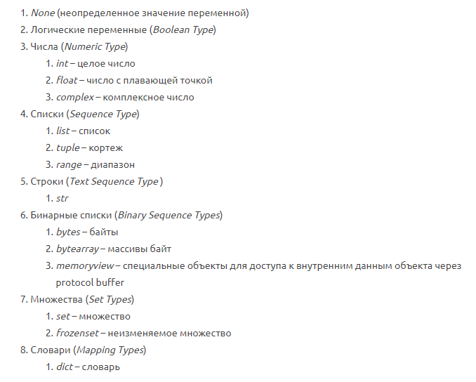

### Проверка на null

*Эквивалент null в Python - это None.* Существует 2 способа проверки на "пустое значение":

- с помощью оператора сравнения "==";
- с помощью "is" (предпочтительный вариант).

```python
class MyClass:
    def __eq__(self, my_object):
        return True

my_class = MyClass()
```

```python
my_class is None
```

```
False
```

**с boolean типом**

```python
0 is False
```

```
False
```

```python
b = 5
```

```python
id(b)
```

```
140735435978656
```

```python
a = 4
```

```python
id(a)
```

```
140735435978624
```

```python
a = b
```

```python
id(a)
```

```
140735435978656
```

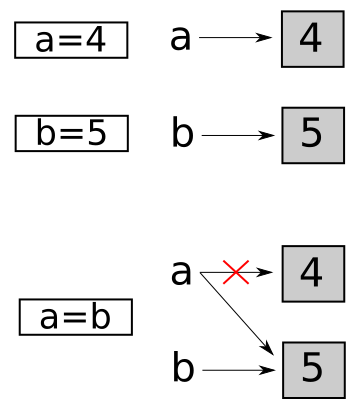

## Циклы

### if-loop

```python
if выражение:
    инструкция_1
    инструкция_2
    ...
    инструкция_n
```

```python
a = 50

if a < 20:
    print('Hi')
elif a > 30:
    print('Elif')
else:
    print('Bye')
```

```
Elif
```

```python
if a > 20:
    print('Hi')
    if a > 30:
        print('I am here')
```

```
Hi
I am here
```

```python
a + 10 if a > 50 else a / 5
```

```
10.0
```

```python
if not a != 50:
    print(" a!= 50")
```

```
 a!= 50
```

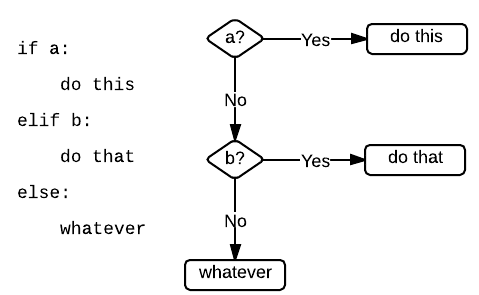

## while-loop

```python
while (expression) :
    statement_1
    statement_2
    ....
```

```python
a = 0
while a < 10:
    print(a)
    a += 1
    if a > 6:
        continue
```

```
0
1
2
3
4
5
6
7
8
9
```

- break
- pass
- continue

## for-loop

```python
elements = [1, 2, 3, 4]
```

```python
for elem in elements:
    print(elem)
```

```
1
2
3
4
```

```python
for i in range(start:stop:step):
    print(i)
```

```python
for i in range(100, 11, -5):
    print(i)
```

```
100
95
90
85
80
75
70
65
60
55
50
45
40
35
30
25
20
15
```

```python
for variable_name in sequence :
    statement_1
    statement_2
    ....
```

```python
for i in range(3):
    print(i)
else:
    print('hi')
```

```
0
1
2
hi
```

### Функция enumerate

применяется для итерируемых коллекций (строки, списки, словари и др.) и создает объект, который генерирует кортежи, состоящие из двух элементов - индекса элемента и самого элемента.

```python
a = [1, 2, 3]
for i in enumerate(a):
    print(i)
```

```
(0, 1)
(1, 2)
(2, 3)
```

```python
for k, i in enumerate(a):
    print('index: ', k, ' eleem: ', i)
```

```
index:  0  eleem:  1
index:  1  eleem:  2
index:  2  eleem:  3
```

Без использования enumerate в цикл пришлось бы вводить переменную-счетчик или извлекать элементы по индексу

**range()** позволяет вам генерировать ряд чисел в рамках заданного диапазона. В зависимости от того, как много аргументов вы передаете функции, вы можете решить, где этот ряд чисел начнется и закончится, а также насколько велика разница будет между двумя числами.

В Python существуют **изменяемые** и **неизменяемые** типы.

К **неизменяемым** (immutable) типам относятся:

- целые числа (int)
- числа с плавающей точкой (float)
- комплексные числа (complex)
- логические переменные (bool)
- кортежи (tuple)
- строки (str)
- неизменяемые множества (frozen set).

К **изменяемым** (mutable) типам относятся:

- списки (list)
- множества (set)
- словари (dict)

## Списки (Lists)

```python
a = [1, 'gtgt', [1, 2, 3]]
```

```python
type(a)
```

```
list
```

```python
a = []
a = list()
```

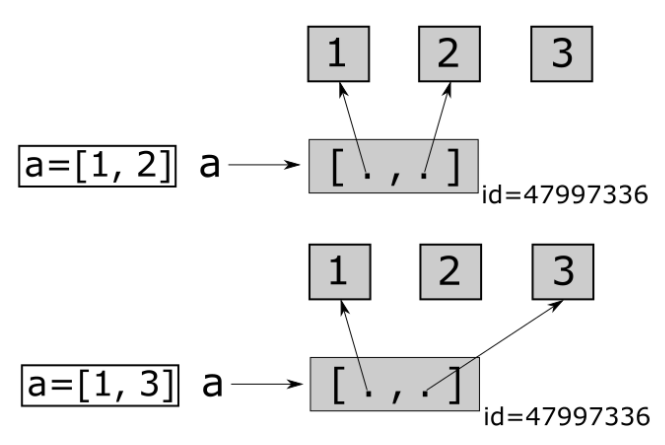

```python
a = []
a = list()
```

```python
a = [1, 2]
```

```python
id(a)
```

```
2632773840640
```

```python
a[1] = 3
a
```

```
[1, 3]
```

```python
id(a)
```

```
2632773840640
```

```python
b = a.copy()
```

```python
a[1] = 3
```

```python
b
```

[output not shown]

a[start:stop:step]

```python
a = [1, 2, 3, 4, 5, 6, 7, 8]
```

```python
a[::-4]
```

```
[8, 4]
```

```python
a[:100]
```

**Доступ к элементам**

**Добавление элементов**

```python
colors.append('Orange')
colors
```

[output not shown]

```python
colors.insert(2, 'Purple')
colors
```

```
['Red', 'Blue', 'Purple', 'Green', 'Black', 'White', 'Orange']
```

**Удаление элементов**

```python
# Deleting an element by its position
del colors[-1]
```

```python
colors = ['Red', 'Blue', 'Green', 'Black', 'White', 'Green']
```

```python
colors
```

[output not shown]

```python
# Removing an item by its value
colors.remove('Green')
```

```python
colors
```

```
['Red', 'Blue', 'Black', 'White', 'Green']
```

**Длина списка**

```python
len(colors)
```

```
5
```

**Цикл**

```python
for color in colors:
    print("Welcome, " + color + "!")
```

```
Welcome, Red!
Welcome, Blue!
Welcome, Black!
Welcome, White!
Welcome, Green!
```

**Элементарные статистики**

```python
nums = [23, 22, 44, 17, 77, 55, 1, 65, 82, 2]
```

```python
sum(nums), min(nums), max(nums)
```

```
(388, 1, 82)
```

**Генератор списка**

```python
squr = []
for i in range(1, 10):
    squr.append(i**2)

squr
```

```
[1, 4, 9, 16, 25, 36, 49, 64, 81]
```

```python
# Using a comprehension to generate a list of square numbers
squr = [x**2 for x in range(1, 11)]
squr
```

```
[1, 4, 9, 16, 25, 36, 49, 64, 81, 100]
```

```python
{x**2:x for x in range(1, 11)}
```

```
{1: 1, 4: 2, 9: 3, 16: 4, 25: 5, 36: 6, 49: 7, 64: 8, 81: 9, 100: 10}
```

## Методы для работы со списками

**list.append(x)** - Добавляет элемент в конец списка

**list.extend(L)** - Расширяет список list, добавляя в конец все элементы списка L

**list.insert(i, x)**- Вставляет на i-ый элемент значение x

**list.remove(x)** - Удаляет первый элемент в списке, имеющий значение x. ValueError, если такого элемента не существует

**list.pop([i])** - Удаляет i-ый элемент и возвращает его. Если индекс не указан, удаляется последний элемент

**list.index(x, [start [, end]])** - Возвращает положение первого элемента со значением x (при этом поиск ведется от start до end)

**list.count(x)** - Возвращает количество элементов со значением x

**list.sort()** - Сортирует список на основе функции

**list.reverse()** - Разворачивает список

**list.copy()** - Поверхностная копия списка

**list.clear()** - Очищает список

## Словарь (Dictionary)

```python
d = {}
d = dict()
```

```python
type(d)
```

```
dict
```

```python
d = {'Red': 1, 'Green': 2, 'Blue': 3, 1: 5}
```

```python
d[True] = 7
```

```python
d
```

```
{'Red': 1, 'Green': 2, 'Blue': 3, 1: 7}
```

```python
d = dict(Red=1, Green=2, Blue=3)
```

**Доступ к элементам**

```python
d['Red']
```

```
1
```

**Изменение элементов словаря**

```python
d['Red'] = 5
d
```

[output not shown]

**Добавление пары ключ:значение**

```python
d['Orange'] = 11
```

```python
d
```

[output not shown]

```python
d.update({'Red':12})
```

```python
d
```

[output not shown]

**Удаление элемента**

```python
d.pop('Red')
d
```

[output not shown]

```python
del d['Green']
```

```python
d
```

```
{'Blue': 3, 1: 7, 'Orange': 11, 'Purple': 12}
```

**Цикл**

```python
for key in d:
    print(d[key])
```

```
3
7
11
12
```

**Вложенный словарь**

```python
myfamily = {
  "child1" : {
    "name" : "Emil",
    "year" : 2004
  },
  "child2" : {
    "name" : "Tobias",
    "year" : 2007
  },
  "child3" : {
    "name" : "Linus",
    "year" : 2011
  }
}
```

```python
myfamily["child1"]["name"]
```

```
'Emil'
```

```python
for child in myfamily:
    print(child)
    print(myfamily[child]['name'])
```

```
child1
Emil
child2
Tobias
child3
Linus
```

## Методы для словарей

**clear()** - Removes all the elements from the dictionary

**copy()** - Returns a copy of the dictionary

**fromkeys()** - Returns a dictionary with the specified keys and values

**get()** - Returns the value of the specified key

**items()** - Returns a list containing a tuple for each key value pair

**keys()** - Returns a list containing the dictionary's keys

**pop()** - Removes the element with the specified key

**popitem()** - Removes the last inserted key-value pair

**setdefault()** - Returns the value of the specified key. If the key does not exist: insert the key, with the specified value

**update()** - Updates the dictionary with the specified key-value pairs

**values()** - Returns a list of all the values in the dictionary

```python
d
```

```python
if 'Purple' in d:
    print("purple")
```

```
purple
```

```python
"Red" in d
```

```
False
```

```python
len(d)
```

```
4
```

## Кортеж (Tuple)

Кортежи по сути те же списки, но есть отличия:

1. Их нельзя изменять
2. Они меньше весят, чем списки

Пример создания кортежа:

```python
tup = ()
tup = tuple()
```

```python
tup = 1,2,3
```

```python
type(tup)
```

```
tuple
```

НО! Скобки ставить необязательно, по сути запятая решает, будет ли строка кортежем:

```python
tup[1] = 0
```

```
---------------------------------------------------------------------------
TypeError                                 Traceback (most recent call last)
<ipython-input-147-73ead4fb8e3c> in <module>
----> 1 tup[1] = 0

TypeError: 'tuple' object does not support item assignment
```

**Изменение элементов**

После создания кортежа элементы изменять **нельзя**!! Кортежи неизменяемы (unchangeable, or immutable). Но есть обходной путь. Можете преобразовать кортеж в список, изменить список и преобразовать список обратно в кортеж.

```python
%%time
x = ("apple", "banana", "cherry")
y = list(x)
y[1] = "kiwi"
x = tuple(y)

x
```

```
Wall time: 0 ns
```

```
('apple', 'kiwi', 'cherry')
```

```python
x.index('apple', 0, 2)
```

```
0
```

В Pyhon функция zip позволяет пройтись одновременно по нескольким итерируемым объектам. выражение zip(a, b) создает объект-итератор, из которого при каждом обороте цикла извлекается кортеж, состоящий из двух элементов. Первый берется из списка a, второй - из b.

```python
s = 'abc'
t = (10, 20, 30)
f = (3, 5)

a = zip(s,t,f)
list(a)
```

```
[('a', 10, 3), ('b', 20, 5)]
```

## Методы для кортежей

**count()** - Returns the number of times a specified value occurs in a tuple

**index()** - Searches the tuple for a specified value and returns the position of where it was found

```python
a1 = (1, )
type(a1)
```

```
tuple
```

```python
a1 = ('a')
a2 = ('a')
print(id(a2))
del a1
del a2
```

```
2632700748016
```

```python
a2 = ('a')
id(a2)
```

```
2632700748016
```

```python
id(a1), id(a2)
```

```
---------------------------------------------------------------------------
NameError                                 Traceback (most recent call last)
<ipython-input-173-7a311ec8b2ba> in <module>
----> 1 id(a1), id(a2)

NameError: name 'a1' is not defined
```

```python
a = ['a']
b = ['a']

id(a), id(b)
```

```
(2632789655168, 2632788797568)
```

## Строки (String)

```python
a = """"""
```

**Конкатенация (сложение)**

```python
s1 = 'hello '
s2 = 'world!'
s1 + s2
```

```
'hello world!'
```

```python
s1 * 3
```

```
'hello hello hello '
```

```python
len(s1)
```

**Доступ по индексу**

```python
s1[1]
```

```
'e'
```

## Методы для работы со строками

**len(S)** - Длина строки

**S.find(str, [start],[end])** - Поиск подстроки в строке. Возвращает номер первого вхождения или -1:

**S.rfind(str, [start],[end])** - Поиск подстроки в строке. Возвращает номер последнего вхождения или -1:

**S.index(str, [start],[end])** - Поиск подстроки в строке. Возвращает номер первого вхождения или вызывает ValueError:

**S.rindex(str, [start],[end])** - Поиск подстроки в строке. Возвращает номер последнего вхождения или вызывает ValueError:

**S.replace(шаблон, замена)** - Замена шаблона

**S.split(символ)** - Разбиение строки по разделителю

**S.isdigit()** - Состоит ли строка из цифр

**S.isalpha()** - Состоит ли строка из букв

**S.isalnum()** - Состоит ли строка из цифр или букв

**S.islower()** - Состоит ли строка из символов в нижнем регистре

**S.isupper()** - Состоит ли строка из символов в верхнем регистре

**S.isspace()** - Состоит ли строка из неотображаемых символов (пробел, символ перевода страницы ('\f'), "новая строка" ('\n'), "перевод каретки" ('\r'), "горизонтальная табуляция" ('\t') и "вертикальная табуляция" ('\v')):

**S.istitle()** - Начинаются ли слова в строке с заглавной буквы

**S.upper()** - Преобразование строки к верхнему регистру

**S.lower()** - Преобразование строки к нижнему регистру

**S.startswith(str)** - Начинается ли строка S с шаблона str

**S.endswith(str)** - Заканчивается ли строка S шаблоном str

**S.join(список)** - Сборка строки из списка с разделителем S

**ord(символ)** - Символ в его код ASCII

**chr(число)** - Код ASCII в символ

**S.lstrip([chars])** - Удаление пробельных символов в начале строки

**S.rstrip([chars])** - Удаление пробельных символов в конце строки

**S.strip([chars])** - Удаление пробельных символов в начале и в конце строки

## Set (множества)

Множества отличаются от списков тем, что в множествах отсутствуют повторяющиеся элементы.

**Способы создания множеств:**

```
1. С помощью ключевого слова set
2. С помощью фигурных скобок
3. С помощью цикла
```

```python
setx = set()
```

```python
a = set([0, 1, 2, 3, 4, 5, 5])
```

```python
a
```

```
{0, 1, 2, 3, 4, 5}
```

```python
color_set = set()

color_set.add("Red")
print(color_set)

color_set.update(["Blue", "Green"])
print(color_set)
```

```
{'Red'}
{'Red', 'Blue', 'Green'}
```

```python
color_set.pop()
```

```
'Red'
```

```python
color_set.remove('Blue')
```

```python
setx = set(["green", "blue"])
sety = set(["blue", "yellow"])
```

```python
# union
setx | sety
```

```
{'blue', 'green', 'yellow'}
```

```python
# intersection
setx & sety
```

```
{'blue'}
```

```python
# difference
setx - sety
```

```
{'green'}
```

```python
# symmetric difference
setx ^ sety
```

```
{'green', 'yellow'}
```

```python
# issubset
setx <= sety
```

```
False
```

```python
basket = {'apple', 'orange', 'apple', 'pear', 'orange', 'banana'}
basket
```

```
{'apple', 'banana', 'orange', 'pear'}
```

## Функции

Функция в python - объект, принимающий аргументы и возвращающий значение. Обычно функция определяется с помощью инструкции def.

```python
def fun():
    pass
```

```python
def summa(a, b):

    return a + b

summa(2, 3)
```

```
5
```

```python
def func(*args):
    s = 0
    for arg in args:
        print(arg)
        s += arg
    return s
```

```python
func(4, 5, 6, 7, 8, 9)
```

```
4
5
6
7
8
9
```

```
39
```

```python
def func1(**kwargs):
    for key in kwargs:
        print(key, ":", kwargs[key])
    return kwargs
```

В переменной kwargs у нас хранится словарь, с которым мы, опять-таки, можем делать все, что нам заблагорассудится.

```python
func1(a = 1, b = 2, c = 3)
```

```
a : 1
b : 2
c : 3
```

```
{'a': 1, 'b': 2, 'c': 3}
```

##### Анонимные функции, инструкция lambda

Анонимные функции могут содержать лишь одно выражение, но и выполняются они быстрее. Анонимные функции создаются с помощью инструкции lambda.

```python
func = lambda x, y: x + y
```

```python
func(1,2)
```

```
3
```

lambda функции, в отличие от обычной, не требуется инструкция return, а в остальном, ведет себя точно так же:

```python
(lambda x: x**2)(5)
```

```
25
```

Существует и такой вариант записи lambda выражения:

```python
(lambda x, y: x + y)(1, 2)
```

Работа с исключениями

```python
for i in range(10):
    prin("hello!")
```

```
---------------------------------------------------------------------------
NameError                                 Traceback (most recent call last)
<ipython-input-203-aac6bfd526af> in <module>
      1 for i in range(10):
----> 2     prin("hello!")

NameError: name 'prin' is not defined
```

**Исключения**

```python
1 / 0
```

```
---------------------------------------------------------------------------
ZeroDivisionError                         Traceback (most recent call last)
<ipython-input-204-bc757c3fda29> in <module>
----> 1 1 / 0

ZeroDivisionError: division by zero
```

```
 +– ArithmeticError
 |    +– FloatingPointError
 |    +– OverflowError
 |    +– ZeroDivisionError
```

```python
try:
    a = int(input("input number: "))
    b = 1 / a
except:
    print('Error')
```

```
input number: 0
Error
```

```python
print("start")
try:
    val = int(input("input number: "))
    tmp = 10 / val
    print(tmp)
except ValueError as ve:
    print("ValueError! {0}".format(ve))
except ZeroDivisionError as zde:
    print("ZeroDivisionError! {0}".format(zde))
except Exception as ex:
    print("Error! {0}".format(ex))
print("stop")
```

```python
try:
    val = int(input("input number: "))
    tmp = 10 / val
    print(tmp)
except:
    print("Exception")
else:
    print("Final code")
```

```
input number: 3
3.3333333333333335
Final code
```

```python
try:
    raise Exception("Some exception")
except Exception as e:
    print("Exception exception " + str(e))
```

Итераторы

```python
a = [1, 2]
```

```python
dir(a)
```

[output not shown]

```python
type(a)
```

```
list
```

```python
b = a.__iter__()
type(b)
```

```
list_iterator
```

```python
b.__next__()
```

[output not shown]

```python
a = 'hi'
b = a.__iter__()
c = a.__iter__()
```

```python
id(b), id(c)
```

```
(2632789476832, 2632789479280)
```

```python
next(b), next(c)
```

[output not shown]

```python
import test

summa(2, 3)
```

```
5
```

```python
a = range(5)
b = iter(a)
```

```python
for i in b:
    print(i)
    if i == 1:
        break
```

```
0
1
```

```python
for i in b:
    print(i)
```

```
2
3
4
```

Генераторы

Генераторами называют итераторы, определение которых выглядит как определение функций.  
Ещё одно определение: генераторы — функции, которые внутри используют выражение yield. Генераторы не могут возвращать значения, вместо этого выдают элементы по готовности.  
Генератор - это функция, которая возвращает итератор, каждый раз "запоминает" свое состояние и генерирует по одному элементу за раз.

```python
def simple_generator():
    print("generate")
    yield 1
    yield 2
```

```python
simple_generator()
```

```
<generator object simple_generator at 0x00000264FE7FB580>
```

```python
simple_gen = simple_generator()
for x in simple_gen:
    print(x)

for x in simple_gen:
    print(x)
```

```
generate
1
2
```

```python
def simple_generator(val):
    print('hi')
    while val > 0:
        val -= 1
        yield val

gen_iter = simple_generator(5)

for i in gen_iter:
    print(i)

for i in gen_iter:
    print(i)
```

```
hi
4
3
2
1
0
```

```python
next(gen_iter)
```

```python
def squares(start, stop):
    print('Hi')
    for i in range(start, stop):
        yield i * i

generator = squares(1, 5)
```

```python
next(generator)
```

[output not shown]

**Какие есть элементы функционального программирования в python?**

- map
- filter
- reduce
- lambda

**map** позволяет применить какую-либо функцию к любому iterable - объекту:

Функция map() в python имеет следующий синтаксис:

*map(func,* iterables)*

```python
alist = ['1', '2', '3']
alist = map(int, alist)
```

функция возвращает map object который является объектом-генератором. Чтобы получить результат в виде списка, встроенная функция list() может быть вызвана для объекта карты, то есть список list(map(func, *iterables))

```python
my_pets = ['alfred', 'tabitha', 'william', 'arla']

uppered_pets = list(map(str.upper, my_pets))
```

**filter** повзоляет отобрать только определенные элементы (например все числа больше 1)  
*filter(func, iterable)*

```python
alist = [1, 2, 3]
alist = filter(lambda x: x > 1, alist)
```

```python
scores = [66, 90, 68, 59, 76, 60, 88, 74, 81, 65]

def is_A_student(score):
    return score > 75

over_75 = list(filter(is_A_student, scores))

print(over_75)
```

```python
dromes = ("demigod", "rewire", "madam", "freer", "anutforajaroftuna", "kiosk")

palindromes = list(filter(lambda word: word == word[::-1], dromes))

print(palindromes)
```

**reduce** повзоляет произвести какие-либо вычисления над элементами iterable - объекта  
*reduce(func, iterable[, initial])* - где **func** это функция, к которой кумулятивно применяется каждый элемент **iterable**, а **initial** необязательное значение, которое помещается перед элементами итерируемого в вычислении и служит значением по умолчанию, когда итерируемый объект пуст.

```python
from functools import reduce

numbers = [3, 4, 6, 9, 34, 12]

def custom_sum(first, second):
    return first + second

result = reduce(custom_sum, numbers)
print(result)

# конечно, гораздо лучше воспользоваться sum:
# summa = sum([1, 2, 3, 4])
```

**модули и пакеты**

```python
# ДЗ
```

```python
# написать свой range, если не указана верхняя граница, то до бесконечности
```

```python
# Номер билетика содержит четное количество цифр.
# Билетик является счастливым, если сумма первой половины цифр == второй половине.
# По номеру билеты определить, является ли он счастливым.
```